# Types of visualizations

## Visualizing median GDP per capita over time

A la hora de detectar tendencias a lo largo del tiempo, lo mejor es hacer uso de los gráficos de línea o line plots. A continuación vamos a representar como ha evolucionado la mediana de la renta per capita a lo largo de los años.

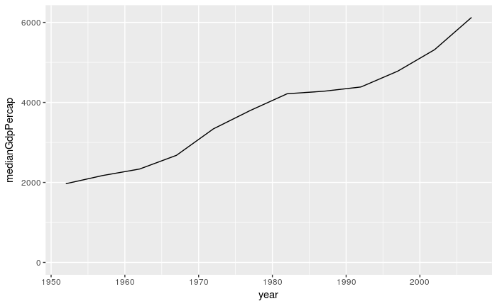

```r
library(gapminder)
library(dplyr)
library(ggplot2)
#Nos creamos nuestro conjunto de datos
by_year <- gapminder %>% group_by(year) %>% summarize(medianGdpPercap = median(gdpPercap))
#Nos creamos el grafo
ggplot(by_year, aes(x = year, y = medianGdpPercap)) + geom_line() + expand_limits(y = 0)
```

## Visualizing median GDP per capita by continent over time

A continuación veremos como ha evolucionado la renta per capita a lo largo del tiempo para cada continente.

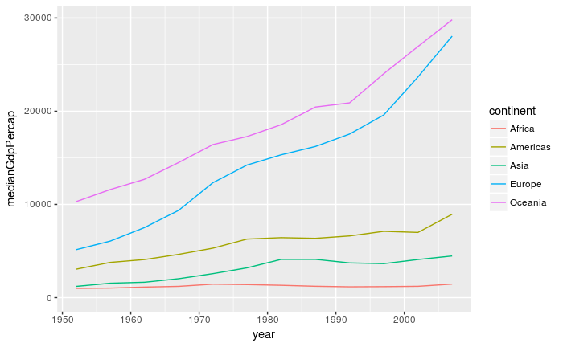

```r
#Nos creamos el dataset
by_year_continent <- gapminder %>% group_by(continent, year) %>% summarize(medianGdpPercap = median(gdpPercap))
#Hacemos el grafo
ggplot(by_year_continent, aes(x = year, y = medianGdpPercap, color = continent)) + geom_line() + expand_limits(y = 0)
```

## Visualizing median GDP per capita by continent

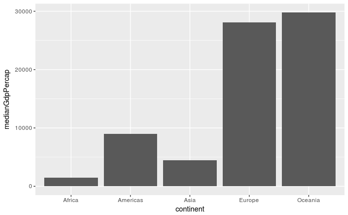

```r
#Nos creamos el dataset
by_continent <- gapminder %>% filter(year == 2007) %>% group_by(continent) %>% summarize(medianGdpPercap = median(gdpPercap))
#Nos creamos el grafo
ggplot(by_continent, aes(x = continent, y = medianGdpPercap)) + geom_col()
```

## Visualizing GDP per capita by country in Oceania

Ahora supongamos que queremos visualizar la renta per capita para un determinado año pero solo en Oceanía.

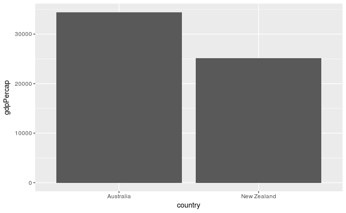

```r
#Nos creamos el dataset
oceania_2007 <- gapminder %>% filter(year == 2007, continent == "Oceania")
#Creamos el grafo
ggplot(oceania_2007, aes(x = country, y = gdpPercap)) + geom_col()
```

## Visualizing population

Los histogramas se tratan de gráficos que nos permiten observar las distribuciones de una variable numérica. A continuación veremos como se destribuye la pobación de nuestro conjunto de datos a lo largo del año 1952.

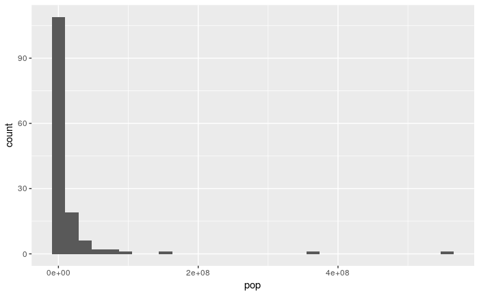

```r
#Nos creamos nuestro datset
gapminder_1952 <- gapminder %>% filter(year == 1952)
#Nos creamos el grafo
ggplot(gapminder_1952, aes(x = pop)) + geom_histogram()
```

## Visualizing population with x-axis on a log scale

Podemos ver como existen determinados países que tienen un población muy superior al resto, esto da lugar a que nuestro histograma no quede muy claro. Para solucionar esto podemos poner nuetro eje X en escala logarítmica.

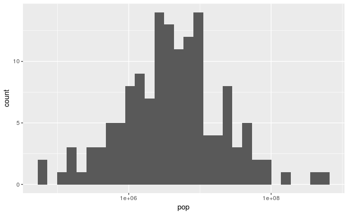

```r
ggplot(gapminder_1952, aes(x = pop)) + scale_x_log10() + geom_histogram(bins = 30)
```

## Comparing GDP per capita across continents

Los gráficos de caja o box plots, se tratan de gráficos que son realmente útiles para comparar distribuciones entre diferentes grupos. A continuación vamos a proceder a ver la distribución de la renta per capita entre los distintos continentes

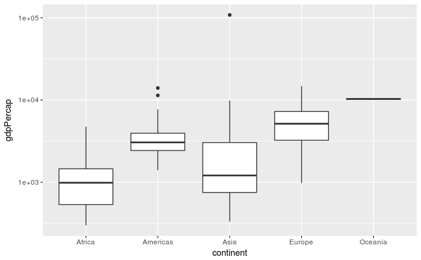

```r
ggplot(gapminder_1952, aes (x = continent, y = gdpPercap)) + scale_y_log10() + geom_boxplot()
```

## Adding a title to your graph

Podemos agregar títulos a nuestro gráficos haciendo uso de **ggtitle()**.

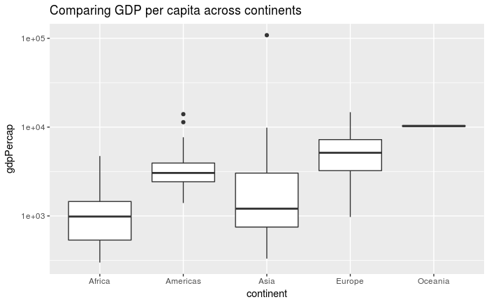

```r
ggplot(gapminder_1952, aes(x = continent, y = gdpPercap)) +
  geom_boxplot() +
  scale_y_log10()+ ggtitle("Comparing GDP per capita across continents")
```